# Megafauna_1

Pedro Jordano

marzo 28, 2014

## Pleistocene megafauna extinctions: functional loss of mutualistic seed dispersal services

### Mauro Galetti, Paulo R. Guimarães Jr., Mathias Pires, Pedro Jordano

#### Regression models. Body mass vs digestive variables. Megafauna.

##### Pedro. Sevilla, 18 Feb 2014.

I used the body mass (g) dataset from:  
Smith, F., S. Lyons, S. Ernest, K. Jones, D. Kaufman, T. Dayan, P. Marquet, J. Brown, and J. Haskell. 2003. Body mass of late quaternary mammals. *Ecology* 84:3403–3403.  
and from:  
Fariña, R. A., S. F. Vizcaíno, and M. S. Bargo. 2004. Body mass estimations in Lujanian (late Pleistocene-early Holocene of South America) mammal megafauna. *Mastozoología Neotropical* 5:87–108.

Our objective is to fit gut capacity (wet weight of content, in g) and gut retention time (in h) to body mass across the full range of body mass for terrestrial mammals. Then we use both the confidence interval for slope and the prediction interval (95%) to estimate the value and range of expected gut capacity and gut retention time of extinct megafauna.  
For these I used the regressions in van Soest (1996). Van Soest, P. J. 1982. *Nutritional Ecology of the Ruminant*. Cornell University Press, NY, USA.

Van Soest, P. J. 1996. Allometry and ecology of feeding behavior and digestive capacity in herbivores: A review. *Zoo Biology* 15:455–479. Owen-Smith, R. N. 1988. *Megaherbivores*. Cambridge University Press, Cambridge, UK.

```r
require(ggplot2)
require(Hmisc)
require(scales)
require(grDevices)
require(dplyr)
```

### Body mass data summary. Extant and extinct taxa.

#### Body mass data for extinct taxa.

Body mass (g) of Late Quaternary mammals MOM database.  
Smith, F., S. Lyons, S. Ernest, K. Jones, D. Kaufman, T. Dayan, P. Marquet, J. Brown, and J. Haskell. 2003. Body mass of late quaternary mammals. *Ecology* 84:3403–3403.

#### *Body mass in g.*

I start by selecting the extinct taxa from Smith et al dataset, getting the body mass information. Then I estimate the regression equations refitting from van Soest’s and add the estiamted values for gut capacity and gut retention time. Finally I use the PanTHERIA dataset to refit the regressions for home range size and population density and estimate the vakues for extinct megafauna. Everything is finally kept in the dataset `prediction`.

```r
bmass_MOM <-read.table("./datasets/MOMv3.3.txt", header=TRUE, sep="\t",
                       dec=".", na.strings="-999")

# Body mass range up to 15000 kg
extinct<- bmass_MOM %.%     # Selecting just the extinct taxa.
    dplyr::filter(status=="extinct") %.%
    dplyr::select(family, genus, species, meanbodymass)
head(extinct)
```

```
##      family        genus   species meanbodymass
## 1   Bovidae   Antidorcas     bondi        34000
## 2   Bovidae   Antidorcas australis        40000
## 3   Bovidae      Gazella atlantica        44500
## 4   Bovidae Megalotragus   priscus       200000
## 5   Bovidae    Pelorovis  antiquus      1000000
## 6 Camelidae      Camelus   thomasi       500000
```

```r
dim(extinct)
```

```
## [1] 242   4
```

```r
# Selecting just the extinct frugivores. Body masses in g.
extinct.frug.megafauna<- bmass_MOM %.%
    dplyr::filter(status=="extinct",
           family== "Elephantidae" |
           family== "Equidae" |
           family== "Gomphotheriidae" |
           family== "Macraucheniidae" |
           family== "Mammutidae" |
           family== "Megalonychidae" |
           family== "Megatheriidae" |
           family== "Mylodontidae") %.%
    dplyr::select(family, genus, species, meanbodymass)
colnames(extinct.frug.megafauna)<- c("family", "genus",
                                     "species", "bmass")
head(extinct.frug.megafauna)
```

```
##         family     genus    species   bmass
## 1      Equidae     Equus   capensis  350000
## 2      Equidae Hipparion    libycum  150000
## 3 Elephantidae   Elephas   iolensis 6500000
## 4      Equidae     Equus    alaskae  372000
## 5      Equidae     Equus laurentius  648000
## 6      Equidae     Equus   caballus  250000
```

```r
dim(extinct.frug.megafauna)
```

```
## [1] 51  4
```

```r
# Here I'm subsetting different functional groups based on genus.
# Selecting different genera with dplyr. *** Body masses in g ***.
# We use these values later to predict average functional traits for
# genera and families.

eremoth<- bmass_MOM %.%
    dplyr::filter(genus=="Eremotherium") %.%
    dplyr::select(species, meanbodymass) %.%
    summarise(mean(meanbodymass))
toxodontids<- bmass_MOM %.%
    dplyr::filter(family=="Toxodontidae") %.%
    dplyr::select(genus, species, meanbodymass) %.%
    summarise(mean(meanbodymass))
equids<- bmass_MOM %.%
    dplyr::filter(family=="Equidae", status=="extinct") %.%
    dplyr::select(genus, species, meanbodymass) %.%
    summarise(mean(meanbodymass))
megatherids<- bmass_MOM %.%
    dplyr::filter(family=="Megatheriidae", status=="extinct") %.%
    dplyr::select(genus, species, meanbodymass) %.%
    summarise(mean(meanbodymass))
gomphotherids<- bmass_MOM %.%
    dplyr::filter(family=="Gomphotheriidae", status=="extinct") %.%
    dplyr::select(genus, species, meanbodymass) %.%
    summarise(mean(meanbodymass))
elephantids<- bmass_MOM %.%
    dplyr::filter(family=="Elephantidae", status=="extinct") %.%
    dplyr::select(genus, species, meanbodymass) %.%
    summarise(mean(meanbodymass))
mylo<- bmass_MOM %.%
    dplyr::filter(family=="Mylodontidae", status=="extinct") %.%
    dplyr::select(genus, species, meanbodymass) %.%
    summarise(mean(meanbodymass))
tags<- c("Eremotherium", "Toxodontidae", "Equidae", "Megatheriidae",
         "Gomphotheriidae", "Elephantidae", "Mylodontidae")
topredict<- data.frame(taxa=tags,
                 bmass= rbind(eremoth, toxodontids, equids,
                              megatherids, gomphotherids,
                              elephantids, mylo))
colnames(topredict)<- c("taxa","bmass") # Body mass in g!
```

### Digestive organ capacity. Extant and extinct taxa.

#### Body mass data for extinct taxa.

Body mass (kg) vs. digestive organ capacity (wet g). Dataset obtained from digitization of figure in van Soest (1982) to fit a new regression equation. *NOTE: Body mass in kg; digestive capacity in g wet content.*

```r
dig.organ<- read.table("./datasets/Body mass (kg) vs Gut capc (g wet).txt",
                       header=TRUE,sep="\t",dec=".",na.strings=".")
# NOTE: dig.organ has Body mass (kg); Gut capacity (g wet).
str(dig.organ)
```

```
## 'data.frame':    64 obs. of  2 variables:
##  $ bmass   : num  0.000167 0.00027 0.000395 0.000785 0.001 ...
##  $ gutcapac: num  0.01 0.065 0.085 0.165 0.112 ...
```

```r
summary(dig.organ)
```

```
##      bmass           gutcapac
##  Min.   :   0.0   Min.   :     0
##  1st Qu.:   0.6   1st Qu.:    67
##  Median :   8.8   Median :   675
##  Mean   : 126.4   Mean   : 14975
##  3rd Qu.:  66.3   3rd Qu.:  8917
##  Max.   :2001.2   Max.   :209200
```

```r
#
# dig.organ <- data.frame(cbind(dig.organ$bmass,
#                               dig.organ$gutcapac,
#                               logbmass=log10(dig.organ$bmass),
#                               loggutcapac=log10(dig.organ$gutcapac)))
```

#### Digestive organ capacity vs. body mass.

*Linear model with log-transformed values.*

```r
lm_fit0<- lm(log10(gutcapac) ~ log10(bmass), data= dig.organ)
summary(lm_fit0)
```

```
##
## Call:
## lm(formula = log10(gutcapac) ~ log10(bmass), data = dig.organ)
##
## Residuals:
##     Min      1Q  Median      3Q     Max
## -0.6574 -0.0930  0.0102  0.1532  0.3573
##
## Coefficients:
##              Estimate Std. Error t value Pr(>|t|)
## (Intercept)    2.0316     0.0270    75.2   <2e-16
## log10(bmass)   1.0020     0.0147    68.0   <2e-16
##
## Residual standard error: 0.203 on 62 degrees of freedom
## Multiple R-squared:  0.987,  Adjusted R-squared:  0.987
## F-statistic: 4.62e+03 on 1 and 62 DF,  p-value: <2e-16
```

```r
gut_with_pred<- data.frame(dig.organ,      # Predicted values for
                                           # plotting.
                           predict(lm_fit0, interval= 'prediction'))
```

#### Regression equation. Digestive organ capacity vs. body mass.

*Linear model with log-transformed values.*

The datatset generated is `prediction`, with body mass (g) and estimated gut capacity (wet g).  
Just the EXTINCT MEGAFAUNA FRUGIVOROUS species. I also generate the predicted mean values for different families.

```r
prediction<- data.frame(extinct.frug.megafauna,
             predgutcap= 10^(2.0316 +
                     1.0020*log10(extinct.frug.megafauna$bmass/1000)))
head(prediction)
```

```
##         family     genus    species   bmass predgutcap
## 1      Equidae     Equus   capensis  350000      38085
## 2      Equidae Hipparion    libycum  150000      16295
## 3 Elephantidae   Elephas   iolensis 6500000     711441
## 4      Equidae     Equus    alaskae  372000      40484
## 5      Equidae     Equus laurentius  648000      70599
## 6      Equidae     Equus   caballus  250000      27185
```

```r
# Dataset with predicted mean values by family.
predfammean<- data.frame(topredict,
    predgutcap= 10^(2.0316 +
            1.0020*log10(topredict$bmass/1000)))
```

### PLOTS. Body mass vs. digestive capacity.

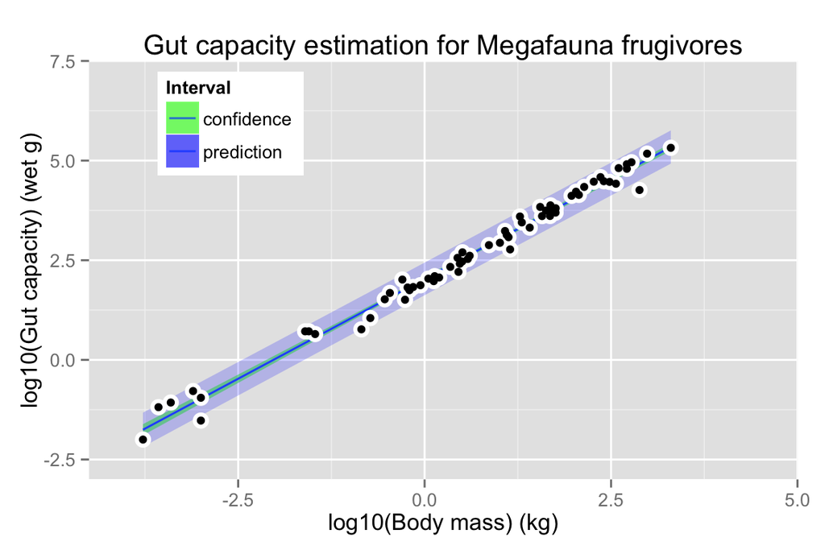

```r
# Log10-scaled axes. Confidence interval for the regression slope.
p0<- ggplot(gut_with_pred, aes(x= log10(bmass),
    y= log10(gutcapac))) +
    geom_point(color="black", size=2) +
    geom_smooth(method= 'lm', aes(fill= 'confidence'), alpha= 0.5) +
    geom_ribbon(aes(y= fit, ymin= lwr, ymax= upr, fill= 'prediction'),
        alpha= 0.2) +
    geom_point(color="white", size=4) +
    geom_point(color="black", size=2) +
    scale_fill_manual('Interval', values= c('green', 'blue')) +
    xlab("log10(Body mass) (kg)") +
    ylab("log10(Gut capacity) (wet g)") +
    ggtitle("Gut capacity estimation for Megafauna frugivores") +
    coord_cartesian(xlim= c(-4.5,5), ylim= c(-3,7.5)) +
    theme(legend.position= c(0.20, 0.85))
p0 # The plot with extant species.
```

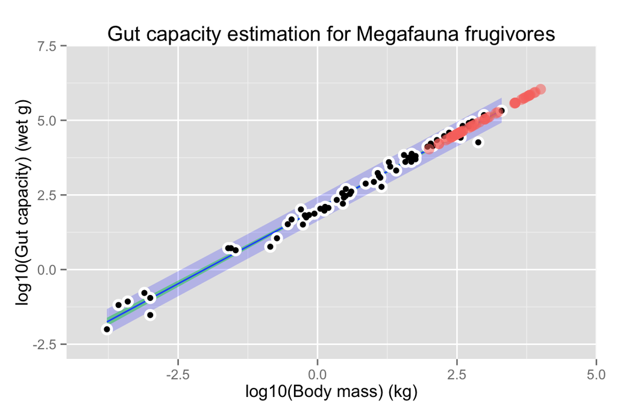

```r
p1<- p0 + geom_point(data= prediction,
                    aes(x= log10(prediction$bmass/1000),
                    y= log10(prediction$predgutcap),
                    color="white", size=2, alpha=0.30)) +
                    theme(legend.position = "none")

# This is the plot. Overlayed
p1
```

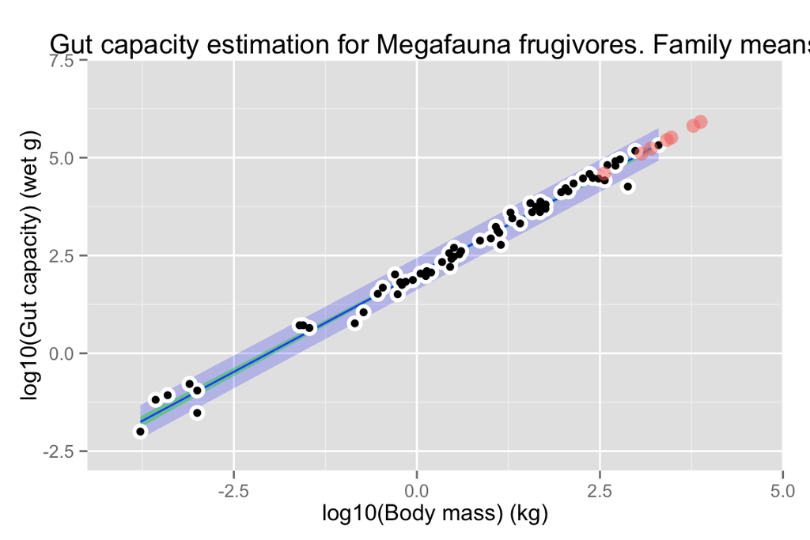

```r
# Plots with averaged data for Extinct megafauna families
p0 + geom_point(data= predfammean, aes(x= log10(predfammean$bmass/1000),
    y= log10(predfammean$predgutcap),
    color="white", size=5, alpha=0.40)) +
    xlab("log10(Body mass) (kg)") +
    ylab("log10(Gut capacity) (wet g)") +
    ggtitle("Gut capacity estimation for Megafauna frugivores. Family means") +
    theme(legend.position = "none")
```

### Retention time in the gut. Extant and extinct taxa.

#### Body mass (kg) vs. gut retention time (h).

*Dataset*

```r
mean.retention <-read.table("./datasets/Body mass (kg)-Mean gut retention (h).txt",
                            header=TRUE,sep="\t",dec=".",na.strings=".")

str(mean.retention)
```

```
## 'data.frame':    30 obs. of  2 variables:
##  $ bmass    : num  163 269 346 372 514 ...
##  $ retention: num  85.8 86.2 72.8 62.9 69.9 ...
```

```r
head(mean.retention)
```

```
##   bmass retention
## 1 162.9     85.84
## 2 269.4     86.16
## 3 345.5     72.80
## 4 372.2     62.87
## 5 514.2     69.93
## 6 689.1     35.55
```

#### Regression equation. Body mass (kg) vs. gut retention time (h).

*Linear model with log-transformed values.* *Refitting with newly digitized data (7Mar2014).*

Regression equation for time and digestion-limited herbivores.  
Body mass (kg) vs. Mean gut retention time (h). Log10-scaled axes. Confidence interval for the regression slope. Body mass range up to 15000 kg. Using van Soest regression equation after I refitted it (`lm_fit1`). Thus I used `lm_fit1` estiamted on van Soest dataset (redigitized). Then applied the regression equation to predict Gut Retention Time for just the EXTINCT MEGAFAUNA FRUGIVOROUS species, which are in the `extinct.frug.megafauna` dataset.

```r
lm_fit1<- lm(log10(retention) ~ log10(bmass), data= mean.retention)
summary(lm_fit1)
```

```
##
## Call:
## lm(formula = log10(retention) ~ log10(bmass), data = mean.retention)
##
## Residuals:
##     Min      1Q  Median      3Q     Max
## -0.2997 -0.1386 -0.0349  0.1601  0.3932
##
## Coefficients:
##              Estimate Std. Error t value Pr(>|t|)
## (Intercept)    1.0193     0.0336    30.3  < 2e-16
## log10(bmass)   0.2356     0.0150    15.7  2.1e-15
##
## Residual standard error: 0.183 on 28 degrees of freedom
## Multiple R-squared:  0.898,  Adjusted R-squared:  0.894
## F-statistic:  247 on 1 and 28 DF,  p-value: 2.05e-15
```

```r
ret_with_pred<- data.frame(mean.retention,  # Predicted values for
                                            #plotting.
    predict(lm_fit1, interval= 'prediction'))
predretfit1=  1.0193 +
              0.2356 * log10(extinct.frug.megafauna$bmass)
prediction<- data.frame(prediction, 10^predretfit1)

colnames(prediction)<- c("family","genus","species","bmass",
                         "predgutcap","predret") # Body mass in g!
head(prediction) # Now the dataset holds all variables.
```

```
##         family     genus    species   bmass predgutcap predret
## 1      Equidae     Equus   capensis  350000      38085   211.6
## 2      Equidae Hipparion    libycum  150000      16295   173.3
## 3 Elephantidae   Elephas   iolensis 6500000     711441   421.1
## 4      Equidae     Equus    alaskae  372000      40484   214.6
## 5      Equidae     Equus laurentius  648000      70599   244.6
## 6      Equidae     Equus   caballus  250000      27185   195.5
```

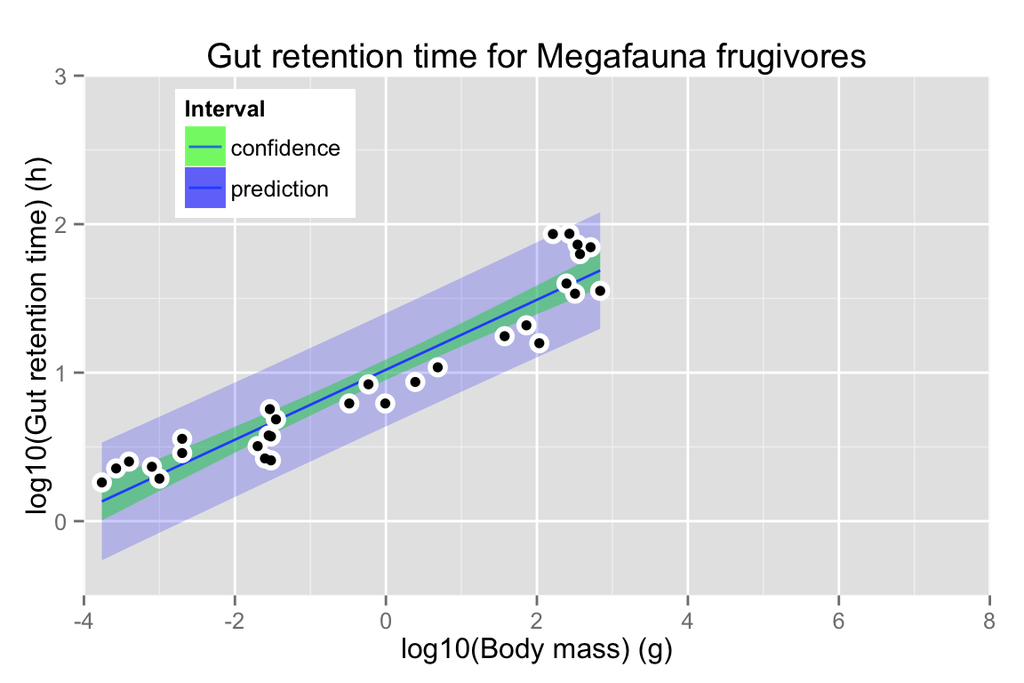

```r
## PLOTS. Body mass (kg) vs. estimated retention time (h).
#### Without log scales.
# New estimations. Log10-scaled axes. Confidence interval for both the
# regression slope and the prediction interval.

p0<- ggplot(ret_with_pred, aes(x= log10(bmass),
    y= log10(retention))) +
    geom_smooth(method= 'lm', aes(fill= 'confidence'), alpha= 0.5) +
    geom_ribbon(aes(y= fit, ymin= lwr, ymax= upr, fill= 'prediction'),
        alpha= 0.2) +
    geom_point(color="white", size=4) +
    geom_point(color="black", size=2) +
    scale_fill_manual('Interval', values= c('green', 'blue')) +
    xlab("log10(Body mass) (g)") +
    ylab("log10(Gut retention time) (h)") +
    ggtitle("Gut retention time for Megafauna frugivores") +
    coord_cartesian(xlim= c(-4,8), ylim= c(-0.5,3)) +
    theme(legend.position= c(0.20, 0.85))
p0 # The plot
```

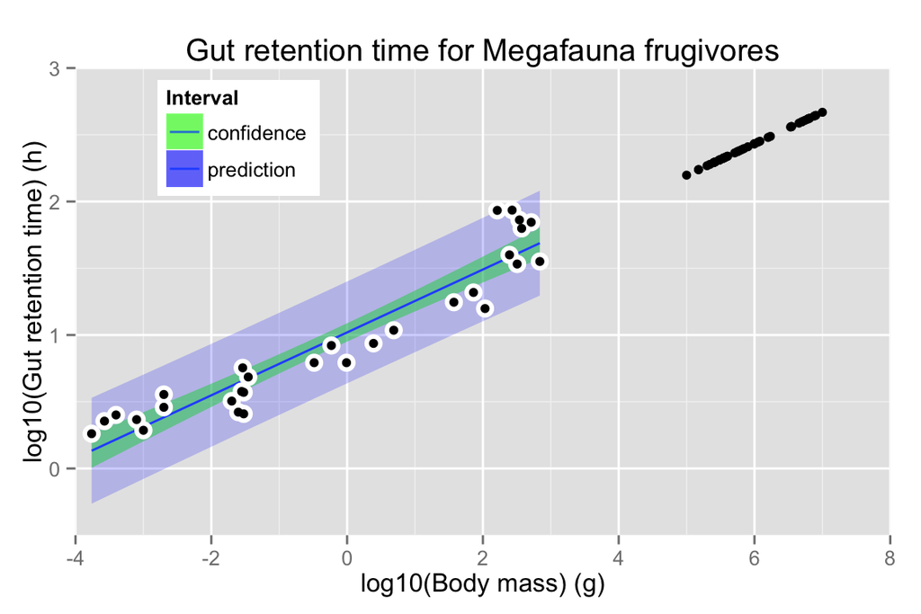

```r
p1<-p0 + geom_point(data= prediction, aes(x= log10(prediction$bmass),
    y= predretfit1))
p1
```

```r
# NOT RUN.
# Plots with averaged data for Extinct megafauna families
#p1 + geom_point(data= predfammean, aes(x= log10(predfammean$bmass),
#    y= log10(predfammean$predretfam)+0.45), size=4, color= "pink") +
#     geom_vline(xintercept= log10(predfammean$bmass),
#                            linetype="dotted")
```

### Dataset for prediction of functional traits, by taxon.

Datatset with body mass (g) and estimated gut capacity (wet g). Using van Soest regression equation, refitted to the body mass data (Smith et al. 2003). For gut retention time I’m using both the raw regression equation (yielding the `predret.vanSoest` predicted values) and the regression equation for time- and digestion-limited herbivores (yielding the `predret.vanSoest.timelim` predicted values).

The regression equation for time- and digestion-limited herbivores is: `gutret.h= 0.57 + 6.95*bmass.kg^0.33 + (0.33 + 0.43 * bmass^0.33)^0.5`

```r
predret= 0.57 + 6.95 * ((extinct.frug.megafauna$bmass/1000)^0.33) +
         (0.33 + 0.43 * (extinct.frug.megafauna$bmass/1000^0.33))^0.5
prediction<- data.frame(prediction, predret)

colnames(prediction)<-  c("family","genus","species","bmass",
    "predgutcap","predret.vanSoest","predret.vanSoest.timelim")

str(prediction)     # Now the dataset holds all the anatomical variables.
```

```
## 'data.frame':    51 obs. of  7 variables:
##  $ family                  : Factor w/ 152 levels "Abrocomidae",..: 45 45 43 45 45 45 45 45 45 45 ...
##  $ genus                   : Factor w/ 1247 levels "Abditomys","Abrawayaomys",..: 362 471 347 362 362 362 362 362 362 362 ...
##  $ species                 : Factor w/ 3451 levels "abae","abbreviatus",..: 540 1715 1492 61 1649 487 1078 2192 676 1161 ...
##  $ bmass                   : num  350000 150000 6500000 372000 648000 250000 259000 334000 400000 400000 ...
##  $ predgutcap              : num  38085 16295 711441 40484 70599 ...
##  $ predret.vanSoest        : num  212 173 421 215 245 ...
##  $ predret.vanSoest.timelim: num  173 118 661 178 228 ...
```

```r
head(prediction)
```

```
##         family     genus    species   bmass predgutcap predret.vanSoest
## 1      Equidae     Equus   capensis  350000      38085            211.6
## 2      Equidae Hipparion    libycum  150000      16295            173.3
## 3 Elephantidae   Elephas   iolensis 6500000     711441            421.1
## 4      Equidae     Equus    alaskae  372000      40484            214.6
## 5      Equidae     Equus laurentius  648000      70599            244.6
## 6      Equidae     Equus   caballus  250000      27185            195.5
##   predret.vanSoest.timelim
## 1                    172.7
## 2                    118.1
## 3                    661.3
## 4                    177.5
## 5                    228.3
## 6                    148.4
```

Home range and population density estimates are obtained from the PanTHERIA dataset in the next sections.

### Dataset for prediction of home range size and population density, by taxon.

Using the PanTHERIA dataset. Jones, K. E., J. Bielby, M. Cardillo, S. A. Fritz, J. ODell, C. D. L. Orme, K. Safi, W. Sechrest, E. H. Boakes, C. Carbone, C. Connolly, M. J. Cutts, J. K. Foster, R. Grenyer, M. Habib, C. A. Plaster, S. A. Price, E. A. Rigby, J. Rist, A. Teacher, O. R. P. Bininda-Emonds, J. L. Gittleman, G. M. Mace, and A. Purvis. 2009. PanTHERIA: a species-level database of life history, ecology, and geography of extant and recently extinct mammals. *Ecology-Ecological Archives* 90:2648.

#### Body mass vs home range size (PanTHERIA dataset).

Body mass (g) vs. home-range area ($km^2$). I have already trimmed the species with missing data.

```r
pantheria.hr <-read.table("./datasets/mypantheria_hr.txt",
                    header=TRUE, sep="\t", dec=".", na.strings="-999")
```

#### Regression equation. Body mass (kg) vs. home range area ($km^2$).

*Linear model with log-transformed values.* Refitting with the trimmed data to exclude those species with `NA's`.

```r
lm_fit5<- lm(log10(homerangekm2) ~
             log10(bmass/1000),
             data= pantheria.hr)
summary(lm_fit5)
```

```
##
## Call:
## lm(formula = log10(homerangekm2) ~ log10(bmass/1000), data = pantheria.hr)
##
## Residuals:
##     Min      1Q  Median      3Q     Max
## -2.6125 -0.6081 -0.0204  0.6186  2.5876
##
## Coefficients:
##                   Estimate Std. Error t value Pr(>|t|)
## (Intercept)        -1.2070     0.0336   -35.9   <2e-16
## log10(bmass/1000)   1.0435     0.0272    38.3   <2e-16
##
## Residual standard error: 0.889 on 698 degrees of freedom
## Multiple R-squared:  0.678,  Adjusted R-squared:  0.677
## F-statistic: 1.47e+03 on 1 and 698 DF,  p-value: <2e-16
```

```r
hr_with_pred<- data.frame(pantheria.hr,   # Predicted values for plotting.
                          predict(lm_fit5, interval= 'prediction'))
# head(hr_with_pred)
prediction<- data.frame(prediction,
                        predhomerange= 10^(-1.2070 +
                                1.0435*log10(prediction$bmass/1000)))
# head(prediction)
```

#### Plots. Body mass (kg) vs. home range area ($km^2$).

Log10-scaled axes. Confidence interval for the regression slope.

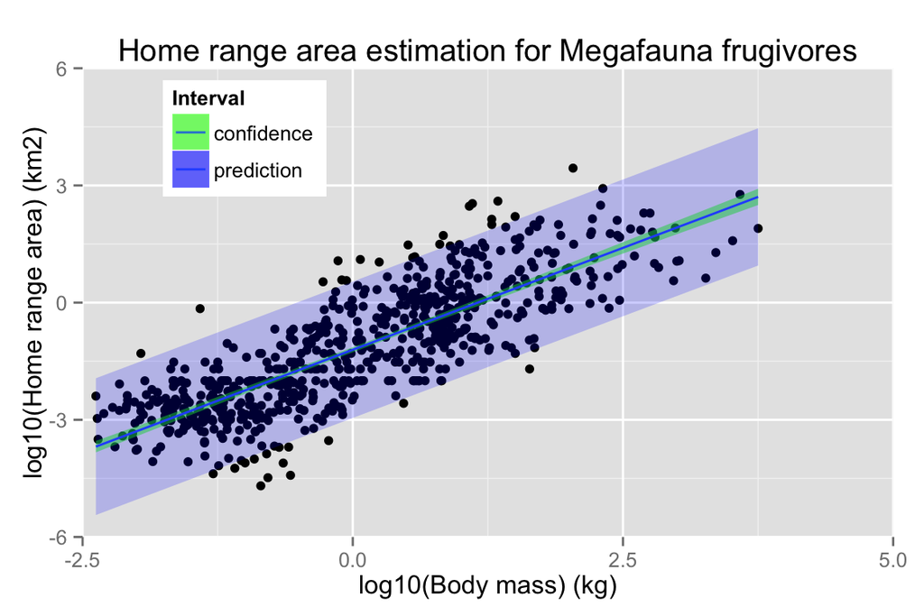

```r
## PLOTS. Body mass (kg) vs. home range area (km2).
#### Without log scales.
# New estimations. Log10-scaled axes. Confidence interval for both the
# regression slope and the prediction interval.
p0<- ggplot(hr_with_pred, aes(x= log10(bmass/1000),
    y= log10(homerangekm2))) +
    geom_point(color="black", size=2) +
    geom_smooth(method= 'lm', aes(fill= 'confidence'), alpha= 0.5) +
    geom_ribbon(aes(y= fit, ymin= lwr, ymax= upr, fill= 'prediction'),
        alpha= 0.2) +
    scale_fill_manual('Interval', values= c('green', 'blue')) +
    xlab("log10(Body mass) (kg)") +
    ylab("log10(Home range area) (km2)") +
    ggtitle("Home range area estimation for Megafauna frugivores") +
    coord_cartesian(xlim= c(-2.5,5), ylim= c(-6,6)) +
    theme(legend.position= c(0.20, 0.85))
p0 # The plot
```

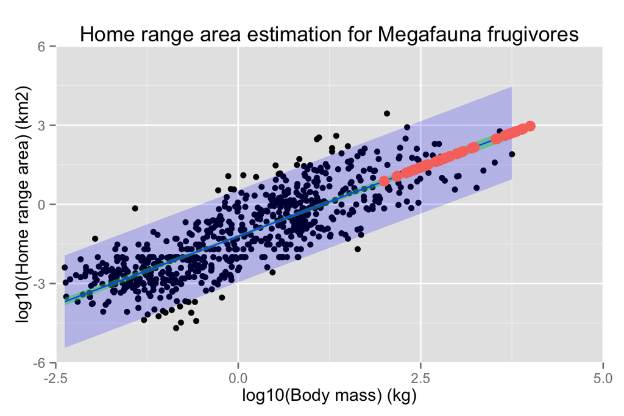

```r
p1<-p0 + geom_point(data= prediction, aes(x= log10(prediction$bmass/1000),
    y= log10(prediction$predhomerange),
    color="white", size=4)) +
    theme(legend.position = "none")
p1
```

### Dataset for prediction of population density, by taxon.

I have already trimmed the species with missing data. Refitting with the trimmed data to exclude those species with `NA's`. Body mass (g) vs. population density (no. ind/km2).

#### Regression equation. Body mass vs population density (PanTHERIA dataset).

*Linear model with log-transformed values.*

```r
pantheria.popdens <-read.table("./datasets/mypantheria_popdens.txt",
    header=TRUE, sep="\t", dec=".", na.strings="-999")

# Regression equation.
# Linear model with log-transformed values.
lm_fit6<- lm(log10(popdens.n.km2) ~
             log10(bmass/1000),
             data= pantheria.popdens)
summary(lm_fit6)
```

```
##
## Call:
## lm(formula = log10(popdens.n.km2) ~ log10(bmass/1000), data = pantheria.popdens)
##
## Residuals:
##     Min      1Q  Median      3Q     Max
## -3.0285 -0.4609  0.0476  0.5965  2.1352
##
## Coefficients:
##                   Estimate Std. Error t value Pr(>|t|)
## (Intercept)         1.6767     0.0367    45.7   <2e-16
## log10(bmass/1000)  -0.7976     0.0294   -27.1   <2e-16
##
## Residual standard error: 0.866 on 557 degrees of freedom
## Multiple R-squared:  0.569,  Adjusted R-squared:  0.568
## F-statistic:  736 on 1 and 557 DF,  p-value: <2e-16
```

```r
popdens_with_pred<- data.frame(pantheria.popdens,
                                    # Predicted values for plotting.
                                predict(lm_fit6, interval= 'prediction'))
# head(popdens_with_pred)

prediction<- data.frame(prediction,
                        predpopdens= 10^(1.6767 +
                            -0.7976*log10(prediction$bmass/1000)))
# head(prediction)
```

#### Plots. Body mass (kg) vs. Population density (ind/km).

Log10-scaled axes. Confidence interval for the prediction and the regression slope.

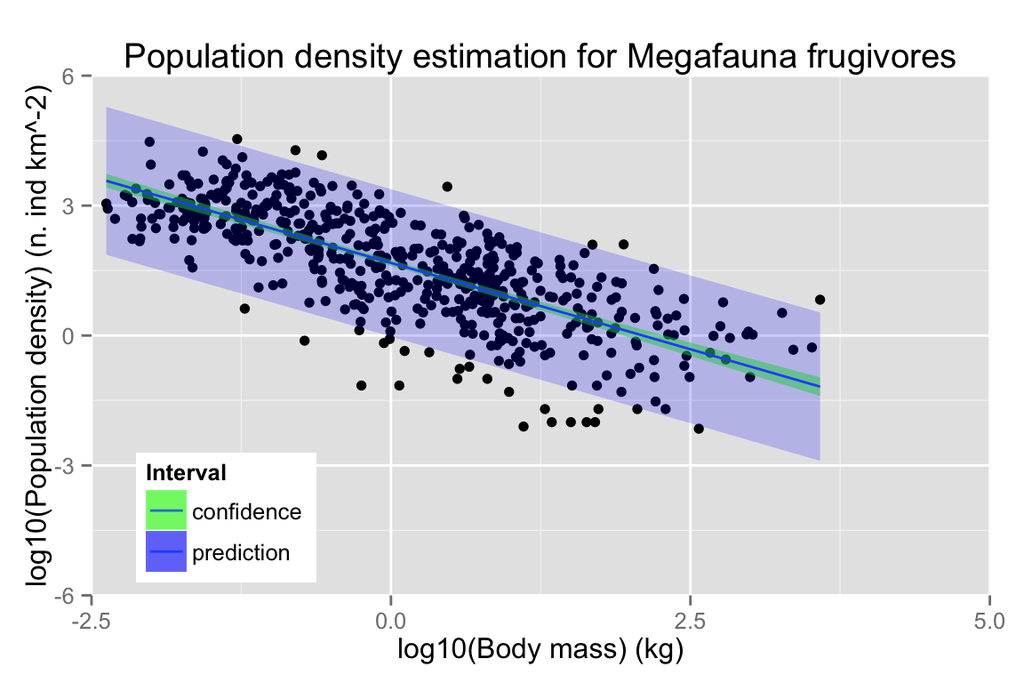

```r
p0<- ggplot(popdens_with_pred, aes(x= log10(bmass/1000),
    y= log10(popdens.n.km2))) +
    geom_point(color="black", size=2) +
    geom_smooth(method= 'lm', aes(fill= 'confidence'), alpha= 0.5) +
    geom_ribbon(aes(y= fit, ymin= lwr, ymax= upr, fill= 'prediction'),
        alpha= 0.2) +
    scale_fill_manual('Interval', values= c('green', 'blue')) +
    xlab("log10(Body mass) (kg)") +
    ylab("log10(Population density) (n. ind km^-2)") +
    ggtitle("Population density estimation for Megafauna frugivores") +
    coord_cartesian(xlim= c(-2.5,5), ylim= c(-6,6)) +
    theme(legend.position= c(0.15, 0.15))
p0 # The plot
```

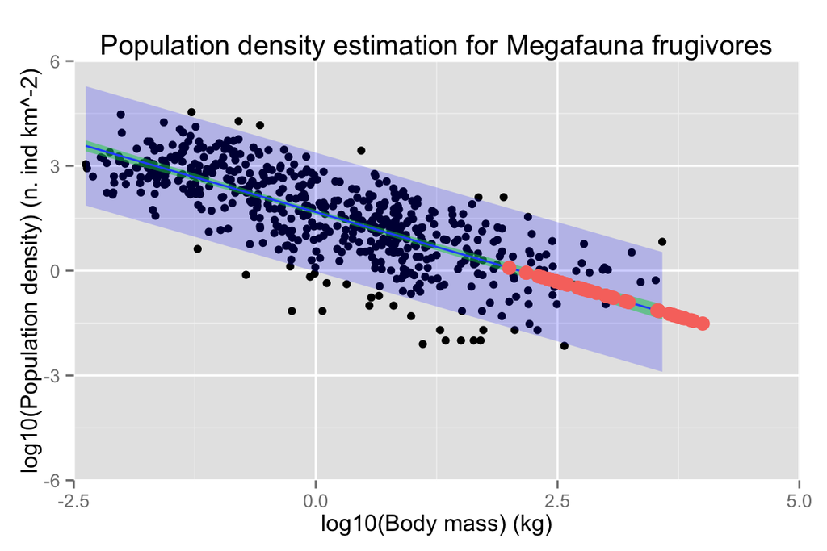

```r
p1<-p0 + geom_point(data= prediction, aes(x= log10(prediction$bmass/1000),
    y= log10(prediction$predpopdens),
    color="white", size=4)) +
    theme(legend.position = "none")
p1
```

## Dataset with estimated values.

This is the dataset with the estimated values of functional traits based on the body mass data. The `predict` dataset holds all the estiamted values based on body masses.

We predict specific values of gut capacity and gut retention from body mass data for just the EXTINCT MEGAFAUNA FRUGIVOROUS species, and using van Soest’s equation modified for time- and digestion-limited herbivores.

Then we predict home range area and population density, also from body mass data but using fits from the PanTHERIA dataset.

```r
# Listing the data.
# Output to a csv file.
write.table(prediction, file = "pred_datatset.csv", sep = ",",
            quote= F, row.names= F, col.names = T, na= "NA")

# Output to the console.
prediction
```

```
##             family           genus       species    bmass predgutcap
## 1          Equidae           Equus      capensis   350000      38085
## 2          Equidae       Hipparion       libycum   150000      16295
## 3     Elephantidae         Elephas      iolensis  6500000     711441
## 4          Equidae           Equus       alaskae   372000      40484
## 5          Equidae           Equus    laurentius   648000      70599
## 6          Equidae           Equus      caballus   250000      27185
## 7          Equidae           Equus     fraternus   259000      28166
## 8          Equidae           Equus  niobrarensis   334000      36341
## 9          Equidae           Equus   complicatus   400000      43538
## 10         Equidae           Equus     giganteus   400000      43538
## 11         Equidae           Equus      hemionus   250000      27185
## 12         Equidae           Equus  conversidens   306000      33288
## 13         Equidae           Equus  occidentalis   574000      62522
## 14         Equidae           Equus        scotti   555000      60448
```

[output cut: 89 more lines]

### CODE NOT RUN.

##### AVERAGED VALUES FOR FAMILIES.

##### Dataset with predicted mean values by family.

```r
str(prediction)
predfammean<- prediction %.% group_by(family) %.% summarise(mean(bmass),
    mean(predgutcap), mean(predret.vanSoest),
    mean(predret.vanSoest.timelim))
colnames(predfammean)<- c("family","bmass", "gutcapacity",
                      "retention","ret.timelim")
head(predfammean) # Now the dataset holds all variables.

# Plots with averaged data for Extinct megafauna families
p1 + geom_point(data= predfammean, aes(x= log10(predfammean$bmass),
    y= log10(predfammean$retention)), size=4, color= "pink", alpha=0.5) +
    geom_vline(xintercept= log10(predfammean$bmass),
        linetype="dotted")

# Based on regressions. -------------------------------------------------
# Gut capacity (g).
predfammean<- data.frame(topredict,
        predgutcap= 10^(2.0316 +
                1.0020*log10(topredict$bmass/1000)))

# Gut retention time. Raw model, van Soest.
predfamret= 10^(1.0193 +
    0.2356 * log10(topredict$bmass/1000))

# Gut retention time. Model for time-limited foragers, van Soest.
predfamrettimelim= 0.57 + 6.95 * ((topredict$bmass/1000)^0.33) +
    (0.33 + 0.43 * (topredict$bmass/1000^0.33))^0.5

predfammean<- data.frame(predfammean, predfamret, predfamrettimelim)
colnames(predfammean)<-  c("family","genus","species","bmass",
    "predgutcap","predret.vanSoest","predret.vanSoest.timelim")
head(predfammean) # Now the dataset holds all variables.
# -----------------------------------------------------------------------
```